# Prueba t: hipótesis y direccionalidad

Sesión del miércoles, 26 de agosto de 2026

# 1 Retomemos el ejercicio anterior

En el práctico anterior dejamos un ejercicio para trabajar de manera autónoma:

> **¿Es el ingreso laboral promedio de las mujeres con hijos distinto al ingreso laboral promedio de las mujeres sin hijos?**

En este ejercicio queremos comparar los ingresos de ambos grupos. Pero antes de realizar la prueba debemos distinguir entre **lo que observamos en nuestra muestra** y **lo que queremos afirmar sobre la población**.

> **Si encontramos una diferencia entre los dos grupos en nuestra muestra, ¿significa que esa diferencia también existe en la población?**

**No necesariamente.**

Si seleccionáramos otra muestra de mujeres ocupadas, probablemente obtendríamos promedios algo distintos debido a la **variabilidad muestral**.

Por eso debemos distinguir:

- **Descripción:** ¿qué diferencia observamos en nuestra muestra?
- **Inferencia:** ¿qué evidencia nos entrega esa muestra sobre una posible diferencia en la población?

## 1.1 Carguemos los datos

Trabajaremos nuevamente con un subconjunto procesado de la **Encuesta CASEN 2022**.

Primero cargamos la base:

```r
load(
  url(
    "https://github.com/cursos-metodos-facso/datos-ejemplos/raw/main/proc_casen.RData"
  )
)
```

Ahora conservaremos las variables necesarias, seleccionaremos inicialmente 1.500 mujeres ocupadas y luego trabajaremos con los casos que tengan información completa en las variables utilizadas.

```r
# Fijamos una semilla para obtener siempre la misma muestra aleatoria
set.seed(123)

# Creamos una base con las variables que necesitamos
goldin_data <- proc_casen |>
  dplyr::select(
    ocupado,
    sexo,
    ytrabajocor,
    hijo
  ) |>

# Conservamos solo a las mujeres ocupadas
  dplyr::filter(
    ocupado == 1,
    sexo == 2
  ) |>

# Seleccionamos aleatoriamente 1.500 casos
  dplyr::sample_n(1500)


# Eliminamos los casos con información faltante
goldin_data <- na.omit(goldin_data)


# Para facilitar la lectura, reemplazaremos los códigos de la variable `hijo` por etiquetas.
goldin_data$grupo_hijo <- factor(
  goldin_data$hijo,
  levels = c(0, 1),
  labels = c(
    "Sin hijos",
    "Con hijos"
  )
)
```

**Nota**

- `|>` es el **pipe nativo de R**. Cumple la misma función general que `%>%`: permite encadenar pasos y leer el código como **“y luego…”**.
- Cuando escribimos `dplyr::filter()`, la forma `paquete::función()` indica de qué paquete proviene la función. Por eso no necesitamos ejecutar `library(dplyr)` antes.

> **Importante:** el paquete sí debe estar instalado en el computador. Si no lo está, primero debemos instalarlo con `install.packages("dplyr")`

## 1.2 Primero observemos nuestra muestra

Antes de realizar una prueba estadística, veamos qué encontramos **descriptivamente**.

```r
goldin_data |>
  # Separamos los datos según si tienen o no hijos
  dplyr::group_by(grupo_hijo) |>
  # Calculamos el tamaño del grupo, la media y la desviación estándar
  dplyr::summarise(
    N = dplyr::n(),
    Media = mean(ytrabajocor),
    SD = sd(ytrabajocor)
  )
```

```
# A tibble: 2 × 4
  grupo_hijo     N   Media      SD
  <fct>      <int>   <dbl>   <dbl>
1 Sin hijos    353 706114. 830191.
2 Con hijos   1098 590848. 638007.
```

Observe los resultados:

> **¿Qué grupo presenta el ingreso promedio más alto?**

> **¿Las medias de los dos grupos son iguales?**

En nuestra muestra observamos que los promedios son diferentes.

Hasta aquí solamente estamos **describiendo la muestra**.

Ahora aparece nuestra pregunta inferencial:

> **¿Esta diferencia entrega evidencia suficiente para pensar que también existe una diferencia en la población?**

## 1.3 Planteemos nuestras hipótesis

Para responder necesitamos establecer un escenario de referencia.

### 1.3.1 Hipótesis nula: $H_0$

> En la población, **no existen diferencias** en el ingreso laboral promedio entre mujeres sin hijos y mujeres con hijos.

$$H_0:
\mu_{\text{sin hijos}}
-
\mu_{\text{con hijos}}
=
0$$

El valor **0** representa nuestro escenario de referencia: que las dos medias poblacionales no presentan diferencias.

El escenario planteado por $H_0$ **se utiliza como referencia y evaluamos si los datos entregan evidencia suficiente para rechazarlo.**.

La pregunta será entonces:

> **¿La diferencia que observamos en nuestra muestra es suficientemente grande, considerando su variabilidad, como para cuestionar este escenario?**

### 1.3.2 Hipótesis alternativa: $H_A$

> En la población, **existen diferencias** en el ingreso laboral promedio entre mujeres sin hijos y mujeres con hijos.

$$H_A:
\mu_{\text{sin hijos}}
-
\mu_{\text{con hijos}}
\neq
0$$

## 1.4 ¿Qué hace la prueba *t*?

No basta con saber cuánto difieren las medias. También necesitamos considerar la **incertidumbre de esa diferencia**.

La idea central de la prueba puede representarse así:

$$t
\approx
\frac{\text{diferencia observada entre las medias}}
{\text{error estándar de esa diferencia(incertidumbre)}}$$

El estadístico *t* nos indica qué tan grande es la diferencia observada **en relación con su incertidumbre**.

**ImportanteLa idea detrás de *t**

Cuanto más alejado de 0 se encuentre $|t|$, más extremo es el resultado respecto del escenario de diferencia igual a 0 planteado por $H_0$ .

## 1.5 Realicemos la prueba *t*

Recordemos que nuestra pregunta es:

> **¿Los ingresos promedio de ambos grupos son distintos?**

La pregunta busca saber si existe una **diferencia**, pero no establece de antemano cuál de los dos grupos debería tener un promedio mayor. Por lo tanto, nos interesa detectar una diferencia en **cualquiera de las dos direcciones**. Por eso utilizamos una **prueba *t* de dos colas**.

Antes de observar los resultados, utilizaremos $\alpha = .05$ como nuestro **criterio de decisión**. Si obtenemos $p < .05$, consideraremos que existe evidencia suficiente para rechazar $H_0$.

En R, especificamos que nuestra prueba es de **dos colas** mediante:

```r
alternative = "two.sided"
```

Ejecutemos la prueba:

```r
# Realizamos una prueba t de dos colas
test_goldin <- t.test(
  ytrabajocor ~ grupo_hijo,
  data = goldin_data,
  alternative = "two.sided"
)

# Mostramos el resultado completo de la prueba
test_goldin
```

Ahora presentaremos los resultados en una tabla más sencilla de leer.

```r
# Ordenamos los resultados en una tabla
stats.table <- broom::tidy(
  test_goldin,
  conf.int = TRUE
)

# Presentamos la tabla en un formato más fácil de leer
rempsyc::nice_table(
  stats.table,
  broom = "t.test"
)
```

| Method | Alternative | Mean 1 | Mean 2 | M1 - M2 | t | df | p | 95% CI |
| --- | --- | --- | --- | --- | --- | --- | --- | --- |
| Welch Two Sample t-test | two.sided | 706,113.65 | 590,847.70 | 115,265.96 | 2.39 | 492.66 | .017* | [20564.30, 209967.62] |

No necesitamos interpretar todas las columnas al mismo tiempo. Vamos a leerlas siguiendo el razonamiento de nuestra prueba.

### ¿Qué diferencia observamos?

Recuerde el orden de los grupos:

- `Mean 1` = mujeres **sin hijos**.
- `Mean 2` = mujeres **con hijos**.
- `M1 - M2` = diferencia entre ambos promedios:

$$\text{Sin hijos} - \text{Con hijos}$$

En nuestra muestra:

- las mujeres **sin hijos** presentan un ingreso promedio de aproximadamente $706.114;
- las mujeres **con hijos** presentan un ingreso promedio de aproximadamente $590.848;
- la diferencia entre ambos grupos es de aproximadamente $115.266.

> **¿Qué grupo presenta el promedio mayor?**

Hasta aquí seguimos describiendo lo que ocurrió en nuestra muestra.

### ¿Qué nos dice *t*?

Ahora observe la columna `t`.

Como vimos antes, este estadístico resume qué tan grande es la diferencia observada respecto de su incertidumbre.

En este caso:

$$t=2.39$$

> **¿El valor de $|t|$ se encuentra cerca o lejos de 0?**

**Nota¿Qué son los grados de libertad?**

La columna `df` muestra los **grados de libertad** de la prueba. Podemos pensarlos como una medida de **cuánta información tiene la prueba para estimar la variabilidad**. En una prueba *t* de Welch, **R los calcula automáticamente**.

### ¿Qué nos dice el valor *p*?

Observe ahora la columna `p`.

El valor *p* nos ayuda a evaluar **qué tan compatible es nuestro resultado con el escenario planteado por $H_0$**.

La pregunta que responde es:

> **Si $H_0$ fuera cierta, ¿qué tan inusual sería obtener un resultado como el observado o uno más extremo?**

La idea es sencilla:

- un valor *p* **grande** indica que nuestro resultado no sería especialmente extraño si $H_0$ fuera cierta;
- un valor *p* **pequeño** indica que nuestro resultado sería poco frecuente bajo $H_0$ y, por lo tanto, entrega evidencia para cuestionarla.

**NotaNivel de significación**

Para decidir qué consideraremos suficientemente pequeño, antes de realizar la prueba establecemos un nivel de significación, este valor funciona como nuestro **criterio de comparación**:
$$\alpha=.05$$

- si el valor *p* es **menor que .05**, consideramos que el resultado sería poco frecuente si $H_0$ fuera cierta;
- si el valor *p* es **mayor que .05**, no tenemos evidencia suficiente para cuestionar $H_0$.

**Ahora observe su resultado: ¿el valor *p* es menor o mayor que .05?**

En nuestra prueba obtuvimos:

$$p=.017$$

Como **.017 es menor que .05**, el resultado observado sería poco frecuente bajo el escenario planteado por $H_0$.

Por lo tanto, el valor *p* entrega **evidencia en contra de $H_0$**.

**ImportanteCuidado con la interpretación de *p**

El valor *p* **no es la probabilidad de que $H_0$ sea verdadera**.

Por ejemplo, si obtenemos $p=.017$, esto **no significa** que exista un 1,7 % de probabilidad de que $H_0$ sea verdadera.

Significa que, **si $H_0$ fuera cierta**, un resultado como el observado (o uno más extremo) sería poco frecuente.

### Veamos esta evidencia gráficamente

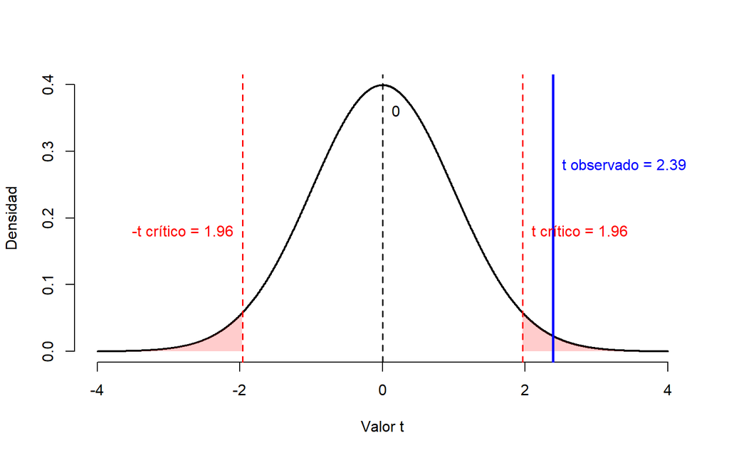

Distribución t de referencia y estadístico t observado.

La curva representa los valores de *t* que podríamos observar si $H_0$ fuera cierta.

Los valores próximos a 0 son más compatibles con ese escenario, mientras que los valores extremos son menos compatibles.

> **¿Nuestro estadístico *t* se encuentra en una zona central o en una zona extrema?**

### ¿Qué nos dice el intervalo de confianza?

Finalmente observe la columna `95% CI`.

Recordemos que $H_0$ plantea una **diferencia igual a 0**.

Por eso preguntamos:

> **¿El intervalo de confianza del 95% incluye el valor 0?**

En nuestro resultado, el intervalo va aproximadamente desde **$20.564 hasta $209.968**.

El intervalo **no contiene 0**.

Por lo tanto, una diferencia poblacional igual a 0 no se encuentra entre los valores compatibles con los datos a este nivel de confianza.

## 1.6 Juntemos la evidencia

Ahora reunamos los distintos elementos de la prueba.

| Resultado | ¿Qué nos permite evaluar? |
| --- | --- |
| `M1 - M2` | Cuánto difieren los promedios en nuestra muestra |
| *t* | Qué tan grande es esa diferencia respecto de su incertidumbre |
| *p* | Qué tan inusual sería el resultado bajo $H_0$ |
| **IC 95%** | Si una diferencia poblacional igual a 0 sigue siendo compatible con los datos |

Todos estos elementos nos ayudan a responder una misma pregunta:

> **¿Tenemos evidencia suficiente para sostener que la diferencia observada en la muestra refleja una diferencia en la población?**

En nuestro resultado:

- observamos una diferencia entre los promedios;
- $|t|=2.39$;
- $p=.017<.05$;
- el IC del 95% no contiene 0.

Estos resultados son **distintas piezas de información relacionadas entre sí.**.

Cuando la prueba está correctamente especificada, estos resultados deben ser coherentes entre sí respecto de la decisión sobre $H_0$. Si aparecen contradicciones entre ellos, conviene revisar las especificaciones de la prueba o los cálculos realizados.

Por lo tanto:

**Con $\alpha=.05$, rechazamos $H_0$.**

## 1.7 Volvamos a nuestra pregunta

> **¿Es el ingreso laboral promedio de las mujeres con hijos distinto al ingreso laboral promedio de las mujeres sin hijos?**

Ya tomamos una decisión estadística. Ahora podemos expresarla en términos de nuestra pregunta.

### ¿Qué observamos en la muestra?

En nuestra muestra, las mujeres **sin hijos** presentan un ingreso laboral promedio mayor que las mujeres **con hijos**, con una diferencia aproximada de **$115.266**.

Esta es nuestra **conclusión descriptiva**: señala lo que observamos en los datos analizados.

### ¿Qué podemos decir sobre la población?

> **Los datos entregan evidencia de que el ingreso laboral promedio difiere entre las mujeres ocupadas con hijos y las mujeres ocupadas sin hijos.**

Esta es nuestra **conclusión inferencial**: la diferencia ya no se refiere solamente a los promedios observados en la muestra, sino a la evidencia que esa muestra entrega sobre una diferencia poblacional.

**Nota¿Qué no podemos concluir?**

Encontrar una diferencia entre ambos grupos **no significa que tener hijos sea la causa de esa diferencia en los ingresos**.

La prueba identifica una diferencia entre grupos, pero no permite establecer una relación causal.

## 1.8 El camino que seguimos en una prueba *t* de dos colas

| Paso | Pregunta que fuimos respondiendo |
| --- | --- |
| **1. Pregunta** | ¿Los promedios de los dos grupos son diferentes? |
| **2. Muestra** | ¿Qué diferencia observamos entre sus medias? |
| **3. Hipótesis** | ¿Qué plantea $H_0$ sobre la diferencia poblacional? |
| **4. Evidencia** | ¿Qué nos dicen *t*, *p* y el IC? |
| **5. Conclusión** | ¿Tenemos evidencia de una diferencia en la población? |

En este ejercicio buscamos una diferencia **sin especificar de antemano cuál grupo debía presentar el promedio mayor**. Por eso utilizamos una prueba *t* de **dos colas**.

# 2 ¿Diferentes o uno mayor que otro? La dirección en la prueba *t*

Hasta ahora preguntamos:

> **¿Los ingresos promedio de las mujeres con y sin hijos son distintos?**

Ahora haremos una pregunta más específica:

> **¿Las mujeres sin hijos tienen un ingreso laboral promedio mayor que las mujeres con hijos?**

Los datos y los grupos son los mismos.

**Lo que cambió fue la pregunta.**

## 2.1 ¿“Distinto” y “mayor” significan lo mismo?

**No.**

Cuando preguntábamos:

> **¿Los ingresos promedio de ambos grupos son distintos?**

nos interesaba cualquier diferencia:

- que las mujeres **sin hijos** tuvieran un ingreso promedio mayor;
- o que las mujeres **con hijos** tuvieran un ingreso promedio mayor.

En cambio, ahora nuestra pregunta es:

> **¿Las mujeres sin hijos tienen un ingreso laboral promedio mayor que las mujeres con hijos?**

Aquí ya no nos sirve cualquier diferencia.  
Nos interesa una diferencia **en una dirección específica**:

$$\text{Sin hijos} > \text{Con hijos}$$

**Importante**

Cuando preguntamos si dos grupos son **distintos**, la diferencia puede aparecer en cualquiera de las dos direcciones.

Cuando preguntamos si un grupo es **mayor que otro**, estamos planteando una dirección específica.

## 2.2 ¿Qué signo esperamos en la diferencia?

Nuestra pregunta es:

> **¿Las mujeres sin hijos tienen un ingreso laboral promedio mayor que las mujeres con hijos?**

Antes de formular las hipótesis, recordemos qué estamos comparando:

- `Mean 1` = **Sin hijos**
- `Mean 2` = **Con hijos**

Por lo tanto, la diferencia se calcula como:

$$M1-M2
=
\text{Sin hijos}
-
\text{Con hijos}$$

Si `Mean 1` tiene un promedio mayor que `Mean 2`, esperamos que esta resta sea **positiva**:

$$M1-M2>0$$

Esta es la dirección que plantea nuestra pregunta.

## 2.3 ¿Cómo formulamos nuestras hipótesis?

Hasta ahora hemos expresado nuestra pregunta en palabras:

> **¿Las mujeres sin hijos tienen un ingreso laboral promedio mayor que las mujeres con hijos?**

Ahora queremos expresar esa misma idea como una **hipótesis estadística sobre la población**.

La lógica es la misma que acabamos de utilizar con la diferencia entre las medias:

> Si el primer grupo tiene un promedio mayor que el segundo, la diferencia **Sin hijos − Con hijos** debería ser positiva.

### 2.3.1 De la pregunta a $H_A$

Primero escribimos qué medias poblacionales queremos comparar:

$$\mu_{\text{sin hijos}}
-
\mu_{\text{con hijos}}$$

Ahora incorporamos la dirección planteada por nuestra pregunta.

Como esperamos que el promedio de las mujeres sin hijos sea mayor:

$$\mu_{\text{sin hijos}}
-
\mu_{\text{con hijos}}
>0$$

¿Por qué aparece `> 0`?

Porque si a un número mayor le restamos uno menor, obtenemos un resultado positivo. Por ejemplo:

$$700-600=100>0$$

La misma lógica se aplica a nuestra pregunta: **“mayor” se traduce en una diferencia positiva**.

Por lo tanto, nuestra hipótesis alternativa es:

$$H_A:
\mu_{\text{sin hijos}}
-
\mu_{\text{con hijos}}
>0$$

$H_A$ expresa justamente la dirección que queremos evaluar: que la diferencia poblacional sea **positiva**.

### 2.3.2 ¿Y qué plantea $H_0$?

La hipótesis nula reúne los escenarios que **no muestran la diferencia positiva planteada por $H_A$**:

$$H_0:
\mu_{\text{sin hijos}}
-
\mu_{\text{con hijos}}
\leq0$$

Esto incluye dos posibilidades:

- diferencia igual a 0 → los promedios son iguales;
- diferencia menor que 0 → el promedio de las mujeres sin hijos es menor.

Así, nuestras hipótesis quedan enfrentadas de esta forma:

$$H_A:
\mu_{\text{sin hijos}}
-
\mu_{\text{con hijos}}
>0$$

$$H_0:
\mu_{\text{sin hijos}}
-
\mu_{\text{con hijos}}
\leq0$$

Podemos quedarnos con una regla sencilla:

**ImportantePara formular una hipótesis direccional**

1. Identifique qué grupo aparece primero.
2. Escriba la diferencia entre los grupos.
3. Pregúntese qué signo debería tener esa diferencia según la pregunta.
4. Exprese esa dirección en $H_A$.

> **Primero entendemos qué afirma la pregunta; después escribimos la diferencia y recién entonces decidimos el signo de la hipótesis.**

Ya sabemos qué dirección establece nuestra hipótesis. Ahora veamos cómo esa misma dirección aparece en el estadístico *t*.

## 2.4 ¿Qué signo esperamos en *t*?

Nuestra hipótesis plantea una diferencia positiva:

$$H_A:
\mu_{\text{sin hijos}}
-
\mu_{\text{con hijos}}
>0$$

Si la diferencia observada ocurre en esa misma dirección, esperamos que el estadístico *t* también sea **positivo**.

El signo de *t* conserva la dirección de la diferencia:

- *t* positivo → Mean 1 > Mean 2;
- *t* negativo → Mean 1 < Mean 2.

Por lo tanto:

$$M1-M2>0
\Rightarrow
t>0$$

En nuestro caso:

$$\text{Sin hijos > Con hijos}
\Rightarrow
M1-M2>0
\Rightarrow
t>0$$

Pero hay una distinción importante:

> **No basta con que *t* sea positivo: debe ser significativamente mayor que cero.**

## 2.5 ¿Por qué ahora hablamos de una cola?

En una prueba de dos colas considerábamos resultados extremos en **ambas direcciones**.

Ahora nuestra hipótesis alternativa establece una **dirección específica.**

Por lo tanto, debemos concentrarnos en los resultados extremos que ocurren hacia esa dirección.

> **Por eso utilizaremos una prueba *t* de una cola.**

## 2.6 ¿Cómo indicamos esta dirección en R?

Ya establecimos la dirección de nuestra hipótesis.

Ahora podemos expresarla en R:

```r
# Realizamos una prueba t de una cola.
test_una_cola <- t.test(
  ytrabajocor ~ grupo_hijo,
  data = goldin_data,
  alternative = "greater"
)

# Mostramos el resultado completo de la prueba
test_una_cola
```

La parte nueva es:

```r
alternative = "greater"
```

`"greater"` significa:

> **Mean 1 > Mean 2**

Como en nuestra comparación:

- `Mean 1` = **Sin hijos**
- `Mean 2` = **Con hijos**

`"greater"` representa la misma dirección que establecimos en $H_A$.

Observemos ahora el resultado de la prueba:

**Código**

```r
stats_una_cola <- broom::tidy(
  test_una_cola,
  conf.int = TRUE
)

rempsyc::nice_table(
  stats_una_cola,
  broom = "t.test"
)
```

| Method | Alternative | Mean 1 | Mean 2 | M1 - M2 | t | df | p | 95% CI |
| --- | --- | --- | --- | --- | --- | --- | --- | --- |
| Welch Two Sample t-test | greater | 706,113.65 | 590,847.70 | 115,265.96 | 2.39 | 492.66 | .009** | [35835.71, Inf] |

## 2.7 ¿Cuándo *t* es suficientemente extremo?

**Ya conocemos nuestro *t* observado. Ahora veamos dónde se encuentra respecto de los valores que consideraríamos suficientemente extremos.**

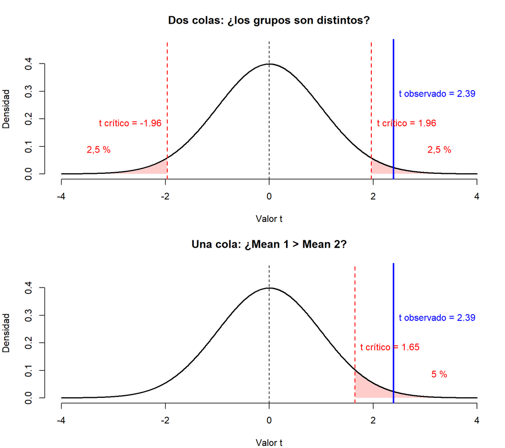

El mismo estadístico t observado en una prueba de dos colas y una prueba de una cola.

En los dos gráficos el *t* observado es el mismo 2.39.

Lo que cambia es dónde ubicamos la región de rechazo:

- en la prueba de **dos colas**, $\alpha=.05$ se reparte entre ambos extremos;
- en la prueba de **una cola**, ese 5 % se concentra en la dirección planteada por $H_A$.

Al cambiar la región de rechazo, también cambia el **valor crítico**.

**NotaEl valor crítico**

El **valor crítico** funciona como una **frontera de decisión**: indica qué tan extremo debe ser nuestro *t* observado para entrar en la región de rechazo de $H_0$. Este límite depende de α, de los grados de libertad y de si la prueba considera una o dos colas.

Ahora concentremos la atención en la prueba de una cola:

**¿Nuestro *t* observado cruza el valor crítico en la dirección de $H_A$, y entra en la región de rechazo?** ¿Consideramos que el resultado es suficientemente extremo para rechazar $H_0$?

En nuestra prueba hacia la derecha:

$$t_{\text{observado}}
>
t_{\text{crítico}}
\Rightarrow
\text{región de rechazo}$$

En nuestro caso, el *t* observado **sí supera el valor crítico**.

Por lo tanto:

> **El resultado entra en la región de rechazo y tenemos evidencia para rechazar la $H_0$ con $\alpha=.05$.**

## 2.8 ¿Por qué cambia *p* si *t* no cambió?

Comparemos directamente ambas pruebas:

| Prueba | t | p |
| --- | --- | --- |
| Dos colas | 2.39 | 0.01716 |
| Una cola | 2.39 | 0.00858 |

> **El valor de *t* permaneció igual, pero el valor *p* cambió. ¿Por qué?**

El t no cambia porque estamos trabajando con los mismos datos y la misma diferencia observada.

Lo que cambia es qué resultados consideramos para calcular el valor p.

En una prueba de dos colas, contamos resultados tan extremos como el observado o más extremos en ambas direcciones:

$$p
=
\text{extremo izquierdo}
+
\text{extremo derecho}$$

En nuestra prueba de una cola hacia la derecha, solo contamos resultados tan extremos o más extremos en la dirección planteada por $H_A$:

$$p
=
\text{extremo derecho}$$

Por eso, en nuestro caso, el área considerada es menor y el valor p también es menor.

> **El t no se hizo más pequeño. Se hizo más pequeña la región de la distribución que utilizamos para calcular p.**

**Importante**

No transformamos manualmente el valor p.

Primero formulamos $H_A$ y después especificamos esa dirección en t.test().

Además, una prueba de una cola no produce siempre un valor p menor: esto ocurre aquí porque el t observado está en la misma dirección planteada por $H_A$.

## ¿Qué nos dice ahora el intervalo de confianza?

Como nuestra hipótesis plantea **una dirección**, el intervalo de confianza también es **unilateral**:

Por eso R entrega un intervalo de la forma:

$$[\text{límite inferior},\ \text{Inf}]$$

Aquí lo importante es observar el **límite inferior**.

En nuestro resultado, el límite inferior es **mayor que 0**. Por lo tanto, el intervalo queda completamente del lado positivo, en la dirección planteada por $H_A$.

Por lo tanto, el intervalo entrega evidencia para poner en duda $H_0$ y es coherente con la hipótesis de que el ingreso promedio de las mujeres sin hijos es mayor.

**Nota**

`Inf` **no significa que la diferencia pueda ser “infinita”**. Aparece porque, en esta prueba direccional, estamos estableciendo un límite inferior y no un límite superior.

**NotaConclusión**

Con
$$\alpha = .05$$
rechazamos $H_0$. Los datos entregan evidencia de que el ingreso laboral promedio de las mujeres sin hijos es mayor que el de las mujeres con hijos.

## 2.9 ¿Qué cambió y qué permaneció igual?

Ahora podemos reunir todo lo que observamos al pasar de una prueba de **dos colas** a una prueba de **una cola**.

Lo importante es recordar que **no cambiamos los datos**. Seguimos comparando a las mismas mujeres, con las mismas medias y la misma diferencia observada.

Lo que cambió fue **la pregunta que queremos responder**.

Podemos verlo como dos niveles diferentes.

### Lo que proviene de los datos

Los datos determinan:

- las medias de los grupos;
- la diferencia `M1 - M2`;
- el estadístico *t*;
- los grados de libertad.

Como los datos son exactamente los mismos, estos elementos **no cambian**.

### Lo que depende de nuestra pregunta

Nuestra pregunta determina:

- qué dirección plantea $H_A$;
- qué extremo de la distribución es relevante;
- dónde queda la región de rechazo;
- cuál es el valor crítico;
- cómo se calcula e interpreta el valor *p*.

Por eso, aunque obtengamos el **mismo *t***, podemos obtener un **valor *p* diferente**.

**ImportanteLa idea central**

Cambiar de una prueba de dos colas a una prueba de una cola **no cambia lo que observamos en los datos**.

Lo que cambia es **cómo evaluamos ese resultado en función de la pregunta y de la hipótesis que formulamos antes del análisis**.

## 2.10 ¿Qué pasa si el resultado va en la dirección contraria?

Nuestra hipótesis plantea:

> **Las mujeres sin hijos tienen un ingreso promedio mayor que las mujeres con hijos.**

Esperamos entonces una diferencia positiva. Por ejemplo:

$$700.000 - 600.000 = 100.000$$

Pero imaginemos que los datos mostraran:

$$550.000 - 700.000 = -150.000$$

y obtuviéramos:

$$t=-3.50$$

El resultado es extremo, pero apunta en la **dirección contraria** a nuestra hipótesis: en este ejemplo, las mujeres sin hijos tendrían un ingreso promedio menor.

> **¿Este resultado apoya $H_A$?**

**No.**

**Importante**

En una prueba direccional no basta con que el resultado sea extremo.

Debe ser extremo **en la dirección planteada por $H_A$**.

# 3 Ejercicio autónomo: ahora decida usted la dirección

Hasta ahora resolvimos juntos una prueba direccional.

Ahora aplicará la misma lógica a una relación diferente utilizando **datos reales de CASEN 2022**.

Queremos comparar los **años de escolaridad** de dos grupos:

- personas de **60 años o más**;
- personas de **18 a 29 años**.

### Preparemos los datos

A partir de `proc_casen`, complete el código para conservar solamente estos dos grupos de edad:

```r
transfer_data <- proc_casen |>
  dplyr::filter(
    (edad >= ___ & edad <= ___) | edad >= ___
  ) |>
  dplyr::mutate(
    grupo_edad = dplyr::case_when(
      edad >= 60 ~ "60 años o más",
      edad >= 18 & edad <= 29 ~ "18 a 29 años"
    )
  )
```

Ahora ordene los grupos para que la comparación sea:

- `Mean 1` = **60 años o más**
- `Mean 2` = **18 a 29 años**

```r
transfer_data$grupo_edad <- factor(
  transfer_data$grupo_edad,
  levels = c(
    "________________",
    "________________"
  )
)
```

Nuestra pregunta es:

> **¿Las personas de 60 años o más presentan, en promedio, menos años de escolaridad que las personas de 18 a 29 años?**

Antes de ejecutar la prueba, responda:

1. **¿Cuál es nuestra hipótesis alternativa $H_A$?**
2. **¿Esperamos una diferencia positiva o negativa entre `Mean 1 - Mean 2`?**
3. **¿Qué signo de *t* sería coherente con nuestra hipótesis?**
4. **¿Qué opción corresponde en `alternative`: `"two.sided"`, `"greater"` o `"less"`?**

Finalmente, complete y ejecute la prueba:

```r
t.test(
  n_educ ~ grupo_edad,
  data = transfer_data,
  alternative = "________"
)
```

Una vez ejecutada la prueba, responda:

1. **¿El signo de *t* coincide con la dirección planteada por $H_A$?**
2. **¿El valor *p* es menor o mayor que $\alpha=.05$?**
3. **¿Rechazamos o no rechazamos $H_0$?**
4. **¿Qué podemos concluir respecto de nuestra pregunta inicial?** Recuerde que la conclusión final debe responder la **pregunta sustantiva**. No basta con indicar si rechazamos o no rechazamos $H_0$.

# 4 Síntesis del práctico

En este práctico trabajamos con la **prueba *t* para comparar dos medias** y vimos cómo la pregunta de investigación determina la forma en que planteamos la prueba.

A lo largo del práctico aprendimos que:

- la prueba *t* compara una diferencia observada con la incertidumbre asociada a esa diferencia;
- el signo de *t* indica la **dirección de la diferencia** entre los grupos;
- el valor *p* nos ayuda a evaluar qué tan compatible es el resultado observado con el escenario planteado por (H_0);
- el intervalo de confianza nos muestra un rango de valores compatibles con los datos;
- en una prueba de **dos colas** nos interesa detectar diferencias en cualquiera de las dos direcciones;
- en una prueba de **una cola** nos interesa evaluar una dirección específica;
- la dirección de la prueba debe definirse **antes de observar los resultados**, a partir de la pregunta y de (H_A).

### ¿Cómo elegimos `alternative`?

| **Pregunta** | **Hipótesis alternativa** | **`alternative`** |
| --- | --- | --- |
| **¿A y B son diferentes?** | $\mu_A - \mu_B \neq 0$ | `"two.sided"` |
| **¿A > B?** | $\mu_A - \mu_B > 0$ | `"greater"` |
| **¿A < B?** | $\mu_A - \mu_B < 0$ | `"less"` |

**ImportantePara recordar**